# Stats Review - Stat 452

Author

Justin Cornejo Leon

```r
library(tidyverse)
library(AmesHousing)
ames <- make_ames()
```

## Exercise 1

### a

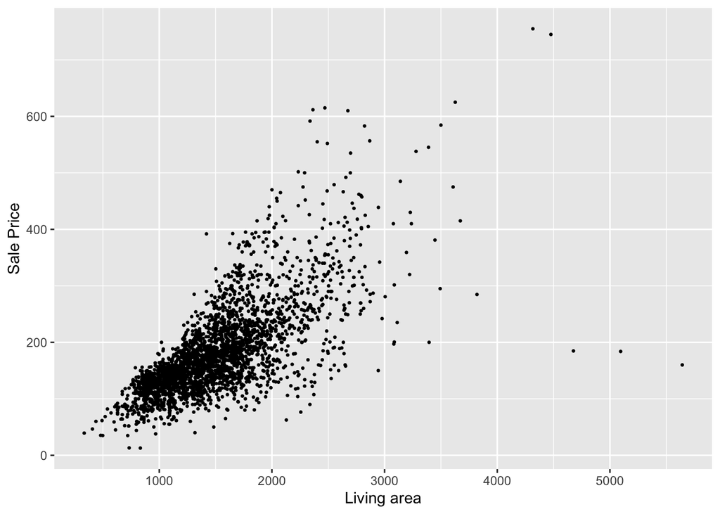

```r
ggplot(ames, aes(x = Gr_Liv_Area, y = Sale_Price / 1000)) + geom_point(size = 0.5) + labs(x = "Living area", y = "Sale Price")
```

The variables Living area and Sale price have a positive relationship according to the graph. As the living area increases, we can see that sale price is also increasing which makes sense in this situation. We do have some outliers but the data seems concentrated for the most part before it fans out.

### b

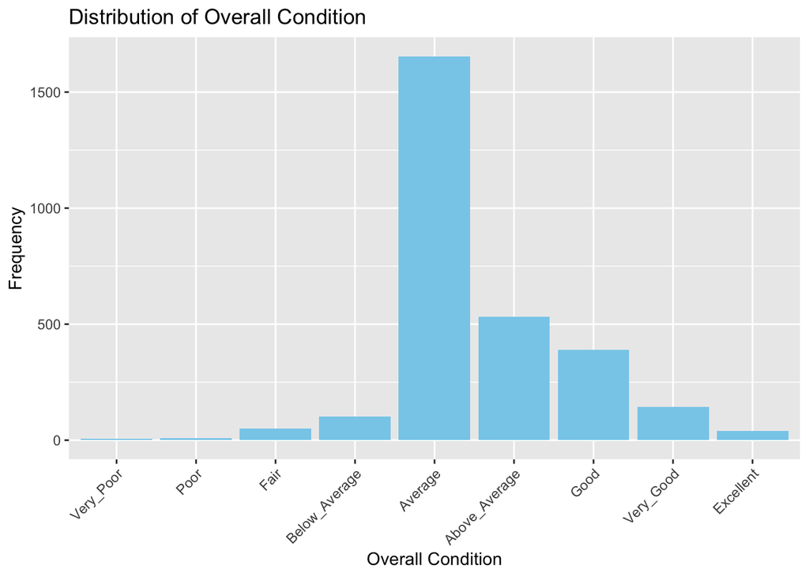

```r
ggplot(ames, aes(x = factor(Overall_Cond))) + geom_bar(fill = "skyblue") +  xlab("Overall Condition") +  ylab("Frequency") + ggtitle("Distribution of Overall Condition") + theme(axis.text.x = element_text(angle = 45, hjust = 1))
```

This bar graph shoes the frequency of the the conditions of the house in the market. We can see that average has a higher frequency than any other category with above average coming in second. The graph shows us a good amount of the homes are either average or above.

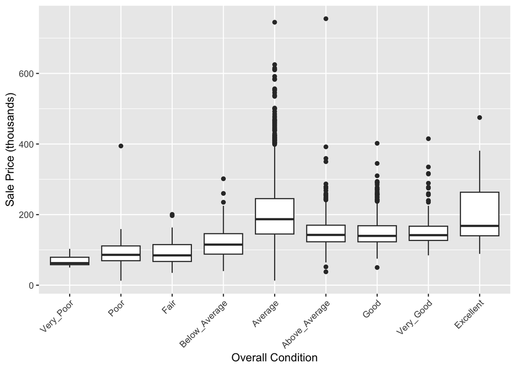

```r
ggplot(ames, aes(x = Overall_Cond, y = Sale_Price / 1000)) + geom_boxplot() + xlab("Overall Condition") + ylab("Sale Price (thousands)") + theme(axis.text.x = element_text(angle = 45, hjust = 1))
```

### c

```r
options(scipen = 999)
lm1 <- lm(Sale_Price ~ Overall_Cond + Gr_Liv_Area, data = ames)
summary(lm1)
```

```
Call:
lm(formula = Sale_Price ~ Overall_Cond + Gr_Liv_Area, data = ames)

Residuals:
    Min      1Q  Median      3Q     Max
-467829  -27023   -3561   23232  325664

Coefficients:
                            Estimate Std. Error t value             Pr(>|t|)
(Intercept)               -92549.799  20259.779  -4.568      0.0000051242820
Overall_CondPoor           56328.764  26104.299   2.158              0.03102
Overall_CondFair           52816.489  21382.196   2.470              0.01356
Overall_CondBelow_Average  64605.309  20704.324   3.120              0.00182
Overall_CondAverage       132019.478  20062.988   6.580      0.0000000000555
Overall_CondAbove_Average 101365.239  20155.538   5.029      0.0000005224426
Overall_CondGood          104135.884  20203.418   5.154      0.0000002714491
Overall_CondVery_Good     105390.155  20505.130   5.140      0.0000002933180
Overall_CondExcellent     116386.681  21663.786   5.372      0.0000000838027
Gr_Liv_Area                  104.282      1.992  52.355 < 0.0000000000000002

(Intercept)               ***
Overall_CondPoor          *
Overall_CondFair          *
Overall_CondBelow_Average **
Overall_CondAverage       ***
Overall_CondAbove_Average ***
Overall_CondGood          ***
Overall_CondVery_Good     ***
Overall_CondExcellent     ***
Gr_Liv_Area               ***
---
Signif. codes:  0 '***' 0.001 '**' 0.01 '*' 0.05 '.' 0.1 ' ' 1

Residual standard error: 52970 on 2920 degrees of freedom
Multiple R-squared:  0.5617,    Adjusted R-squared:  0.5604
F-statistic: 415.8 on 9 and 2920 DF,  p-value: < 0.00000000000000022
```

The reference category for Overall_Cond is “Very Poor”.

Statistically significant: We define a significant variable as a variable with a p-value of less than 0.05. In this case all of the variables are statistically significant.

### d

Interpret Gr_Liv_Area Coefficient: This coefficient represents the change in the predicted sale price for each one-unit increase in the Gr_Liv_Area.

### e

Interpret R<sup>2</sup> : The R<sup>2</sup> is 0.5617, which tells us that approximately 56.17% of the variability in sale prices is explained by the independent variables included in the model.

### f

```r
new_x <- data.frame(Gr_Liv_Area = 1500, Overall_Cond = "Good")
predict(lm1, newdata = new_x)
```

```
       1
168009.2
```

# Exercise 2

### a

```r
set.seed(452)
x <- rnorm(100, mean = 0, sd = 1)
head(x)
```

```
[1] -1.455509526 -0.130277254  1.710965509  2.187875281  0.008381963
[6] -1.621290622
```

### b

```r
set.seed(452)
eps <- rnorm(100, mean = 0, sd = 0.5)
head(eps)
```

```
[1] -0.727754763 -0.065138627  0.855482755  1.093937641  0.004190981
[6] -0.810645311
```

### c

```r
set.seed(452)
x <- rnorm(100, mean = 0, sd = 1)
eps <- rnorm(100, mean = 0, sd = 0.5)

y <- -1 + 0.5 * x + eps

length_y <- length(y)
beta0 <- -1
beta1 <- 0.5

print(length_y)
```

```
[1] 100
```

```r
print(paste("beta0 =", beta0))
```

```
[1] "beta0 = -1"
```

```r
print(paste("beta1 =", beta1))
```

```
[1] "beta1 = 0.5"
```

### d

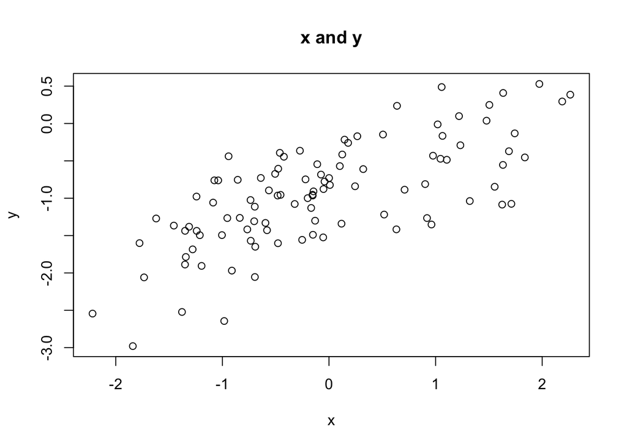

```r
set.seed(452)
x <- rnorm(100, mean = 0, sd = 1)
eps <- rnorm(100, mean = 0, sd = 0.5)

y <- -1 + 0.5 * x + eps
plot(x, y, main = "x and y", xlab = "x", ylab = "y")
```

### e

```r
model <- lm(y ~ x)

beta_hat_0 <- coef(model)[1]
beta_hat_1 <- coef(model)[2]
beta_0 <- -1
beta_1 <- 0.5

print(paste("Estimated beta_0:", beta_hat_0))
```

```
[1] "Estimated beta_0: -0.916178486444764"
```

```r
print(paste("Estimated beta_1:", beta_hat_1))
```

```
[1] "Estimated beta_1: 0.471953097149934"
```

```r
print(paste("True beta_0:", beta_0))
```

```
[1] "True beta_0: -1"
```

```r
print(paste("True beta_1:", beta_1))
```

```
[1] "True beta_1: 0.5"
```

### f

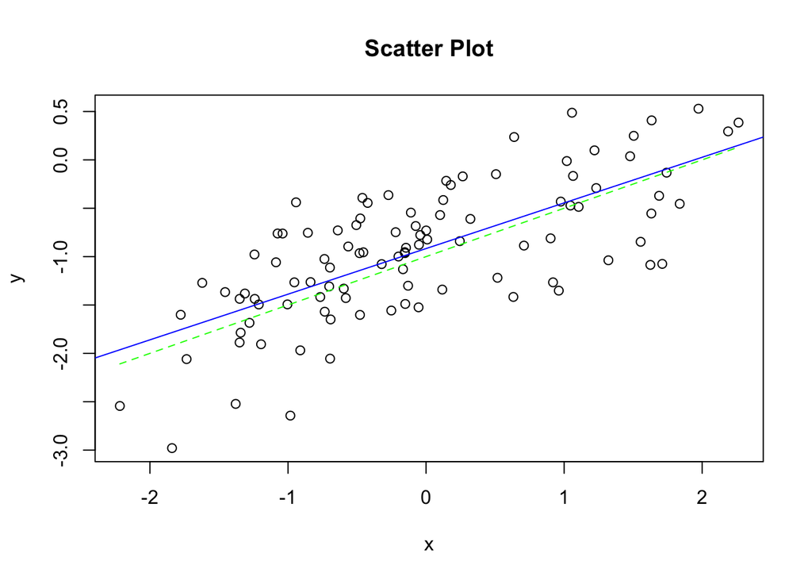

```r
model <- lm(y ~ x)

beta_hat_0 <- coef(model)[1]
beta_hat_1 <- coef(model)[2]

x_values <- seq(min(x), max(x), length.out = 100)

y_values_population <- -1 + 0.5 * x_values
plot(x, y, main = "Scatter Plot", xlab = "x", ylab = "y")

abline(model, col = "blue")
lines(x_values, y_values_population, col = "green", lty = 2)
```

The lines have the same shape and are going in the same direction. This tells us that we have a good estimate in terms of the least square method when it comes to looking at the relationship between x and y.

### g

```r
model <- lm(y ~ x)

conf_intervals <- confint(model)

ci_beta0 <- conf_intervals[1, ]
ci_beta1 <- conf_intervals[2, ]


print("95% Confidence:")
```

```
[1] "95% Confidence:"
```

```r
print(paste("beta0:", paste(ci_beta0, collapse = " - ")))
```

```
[1] "beta0: -1.01360758986166 - -0.81874938302787"
```

```r
print(paste("beta1:", paste(ci_beta1, collapse = " - ")))
```

```
[1] "beta1: 0.378762104790495 - 0.565144089509372"
```

According to the output , we can see that the confidence intervals contain the true values